JuliaActuary

Practical, extensible, and open-source actuarial modeling and analysis.

# Universal Life Policy Account Mechanics as a Differential Equation

## Introduction

This demonstrates an example of defining an universal life policy value roll like a discrete differential equation.

It then uses the [SciML DifferentialEquations](https://sciml.ai/) package to "solve" the policy projection given a single point, but also to see how the policy projection behaves under different premium and interest rate conditions.

The first time this is run, it will download and precompile some large packages.

```julia
begin
    using Dates
    using MortalityTables
    using DifferentialEquations
    using Plots
    using ActuaryUtilities
end
```

Let's use the 2001 CSO table as the basis for cost of insurance charges:

```julia
cso = MortalityTables.table("2001 CSO Super Preferred Select and Ultimate - Male Nonsmoker, ANB")
```

```
MortalityTable (CSO/CET):
   Name:
       2001 CSO Super Preferred Select and Ultimate - Male Nonsmoker, ANB
   Fields:
       (:select, :ultimate, :metadata)
   Provider:
       American Academy of Actuaries
   mort.SOA.org ID:
       1076
   mort.SOA.org link:
       https://mort.soa.org/ViewTable.aspx?&TableIdentity=1076
   Description:
       2001 Commissioners Standard Ordinary (CSO) Super Preferred Select and Ultimate Table – Male Nonsmoker. Basis: Age Nearest Birthday. Minimum Select Age: 0. Maximum Select Age: 99. Minimum Ultimate Age: 16. Maximum Ultimate Age: 120
```

Next, policy mechanics are coded. It's essentially a discrete differential equation, so it leverages [`DifferentialEquations.jl`](https://diffeq.sciml.ai/dev/)

The projection is coded in the [Discrete DifferentialEquation format](https://diffeq.sciml.ai/dev/types/discrete_types/):

$u_{n+1} = f(u,p,t_{n+1})$

In the code below, this translates to:

- `u` is the *state* of the system. We will track three variables to represent the `state`:
  - `state[1]` is the account value
  - `state[2]` is the premium paid
  - `state[3]` is the policy duration
- `p` are the parameters of the system.
- `t` is the time, which will represent days since policy issuance

```julia
function policy_projection(state,p,t)
    # grab the state from the inputs
    av = state[1]

    # calculated variables
    cur_date = p.issue_date + Day(t)
    dur = duration(p.issue_date,cur_date)
    att_age = p.issue_age + dur - 1

    # lapse if AV <= 0
    lapsed = (av <= 0.0 ) & (t > 1)

    if !lapsed

        monthly_coi_rate = (1 - (1-p.mort_assump[att_age]) ^ (1/12))

        ## Periodic Policy elements

        # annual events
        if Dates.monthday(cur_date) == Dates.monthday(p.issue_date) ||
            cur_date ==p.issue_date + Day(1) # OR first issue date

            premium = p.annual_prem
        else
            premium = 0.0
        end

        # monthly_events
        if Dates.day(cur_date) == Dates.day(p.issue_date)
            coi = max((p.face - av) * monthly_coi_rate,0.0)
        else
            coi = 0.0
        end

        # daily events
        int(av) = av * ((1 + p.int_rate) ^ (1 / 360) - 1.0)



        # av
        new_av = max(0.0,av - coi + premium + int(av-coi))

                # new state
        return [new_av, premium, dur] # AV, Prem, Dur

    else
        # new state
        return [0.0, 0.0, dur] # AV, Prem, Dur

    end


end
```

```
policy_projection (generic function with 1 method)
```

The following function will create a named tuple of parameters given a varying `prem` (premium) and `int` (credit rate).

```julia
params(prem,int) = (
    int_rate = int,
    issue_date = Date(2010,1,1),
    face = 1e6,
    issue_age = 25,
    mort_assump = MortalityTables.table("2001 CSO Super Preferred Select and Ultimate - Male Nonsmoker, ANB").ultimate,
    projection_years = 75,
    annual_prem = prem,
)
```

```
params (generic function with 1 method)
```

## Runing the system

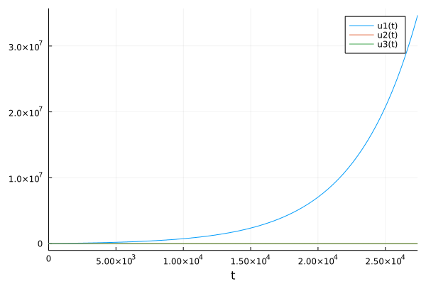

```julia
begin
    p = params(
            8000.0, # 8,000 annual premium
            0.08    # 8% interest
            )

    # calculate the number of days to project
    projection_end_date = p.issue_date + Year(p.projection_years)
    days_to_project = Dates.value(projection_end_date - p.issue_date)

    # the [0.0,..] are the initial conditions for the tracked variables
     prob = DiscreteProblem(policy_projection,[0.0,0.0,0],(0,days_to_project),p)
     proj = solve(prob,FunctionMap())

     plot(proj)
end
```

## Moving up the ladder of abstraction

An excellent way to understand the behavior of a model is to [move up the ladder of abstraction](http://worrydream.com/LadderOfAbstraction/). Below, we will see what happens to the projection at varying levels of credit rates and annual premiums.

The full range of simulated outcomes can take a couple of minutes to run:

```julia
begin
    prem_range = 1000.0:100.0:9000.0
    int_range = 0.02:0.0025:0.08

    function ending_av(ann_prem,int,days_to_project)
        p = params(ann_prem,int)
        prob = DiscreteProblem(policy_projection,[0.0,0.0,0],(0,days_to_project),p)
        proj = solve(prob,FunctionMap())
        end_av = proj[end][1]
        if end_av == 0.0
            lapse_time = findfirst(isequal(0.0),proj[1,2:end])
        else
            lapse_time = length(proj)
        end
        duration = proj[3,lapse_time]
        end_age = p.issue_age + duration - 1.0

        return end_av,end_age

    end

    end_age = zeros(length(prem_range),length(int_range))
    end_av = zeros(length(prem_range),length(int_range))

    # loop through each projection we did and fill our ranges with the ending AV and ending age
    for (i,vp) in enumerate(prem_range)
        for (j,vi) in enumerate(int_range)
            end_av[i,j],end_age[i,j] = ending_av(vp,vi,days_to_project)
        end
    end
end
```

Now let's plot the result. Not surprising, interest has a huge effect on the policy projection. Premium is also a major influence.

One thing that's remarkable is how going from 2000 premium to just ~2200 of premium results in about a 5m difference at 8% interest. The power of compound interest!

```julia
begin
    using ColorSchemes # for Turbo colors, which emphasize readability

    viz = plot(layout=2) # side by side plot

    #
    contour!(viz[1],int_range,
        prem_range,
        end_av ./ 1e6, # scale to millions for readability

        contour_labels=true,
        c=cgrad(ColorSchemes.turbo.colors),
        fill=true,
        title="AV at age 100 (M)",
        ylabel=L"Annual Premium (\$)",
        xlabel="credit rate"


    )

    contour!(viz[2],int_range,
        prem_range,
        end_age,

        contour_labels=true,
        c=cgrad(ColorSchemes.turbo.colors),
        fill=true,
        yaxis=false,
        title="Age at Lapse",
        xlabel="credit rate"
    )

    annotate!(viz[2],[0.055,7000,Plots.text("Doesn't lapse \nbefore age 100", 8, :white, :center)])

end
```

[figure not shown]

```julia
using LaTeXStrings
```

## Conclusion

This shows how universal life mechanics are a dynamic system. the growth/decay is governed by two competing feedback loops:

- Growth: the force of interest lets the balance grow exponentially over long periods of time
- Decay: low balances increase the net amount at risk and the resulting COI charges.

## Endnotes

This is not meant to represent any particular insurance product, nor fully replicate typical account mechanics.

Built with Julia 1.8.5 and

ActuaryUtilities 3.4.2  
ColorSchemes 3.19.0  
DifferentialEquations 7.2.0  
LaTeXStrings 1.3.0  
MortalityTables 2.3.0  
Plots 1.31.2

## Run this Pluto Notebook

To run this page locally, download this file and open it with [Pluto.jl](https://plutojl.org).

The packages in JuliaActuary are open-source and liberally licensed (MIT License) to allow wide private and commercial usage of the packages, like the base Julia language and many other packages in the ecosystem. See terms of this site.

© JuliaActuary Contributors. Last modified: August 19, 2023. Website built with Franklin.jl and [Julia](https://julialang.org).